# BreastCancer_Metabolomics

2026-07-28

[output not shown]

```r
raw_data <- read.delim(
  "data/MSdata_ST000355_AN000581.txt",
  header = TRUE,
  check.names = FALSE,
  stringsAsFactors = FALSE
)
```

Then recreate metadata and metab exactly like this:

```r
metadata <- raw_data |>
  slice(1)

metab <- raw_data |>
  slice(-1)
```

Now check

```r
head(metab$Samples)
```

```
## [1] "18-Hydroxycorticosterone"      "1-Pyrroline-2-carboxylic acid"
## [3] "2_3-Diaminopropionic acid"     "2-Hydroxycinnamic acid"
## [5] "3-Hydroxydodecanedioic acid"   "3-Indolepropionic acid"
```

Do not run mutate(across(everything(), as.numeric)) this time.

Instead, convert all columns except Samples:

```r
metab <- metab |>
  mutate(
    across(-Samples, as.numeric)
  )
head(metab$Samples)
```

```
## [1] "18-Hydroxycorticosterone"      "1-Pyrroline-2-carboxylic acid"
## [3] "2_3-Diaminopropionic acid"     "2-Hydroxycinnamic acid"
## [5] "3-Hydroxydodecanedioic acid"   "3-Indolepropionic acid"
```

Next step: Transpose the metabolite matrix

We’ll make the metabolite names become the column names and the samples become the rows.

```r
library(tibble)

metab_t <- metab |>
  column_to_rownames("Samples") |>
  t() |>
  as.data.frame() |>
  rownames_to_column("Sample") |>
  as_tibble()
```

#glimpse(metab_t)

```r
glimpse(metab_t)
```

```
## Rows: 211
## Columns: 101
## $ Sample                                       <chr> "PN01935", "PN02020", "PN…
## $ `18-Hydroxycorticosterone`                   <dbl> 0.0162, 0.0153, 0.0136, 0…
## $ `1-Pyrroline-2-carboxylic acid`              <dbl> 0.2309, 0.2990, 0.3401, 0…
## $ `2_3-Diaminopropionic acid`                  <dbl> 0.1919, 0.2138, 0.1488, 0…
## $ `2-Hydroxycinnamic acid`                     <dbl> 0.0161, 0.0206, 0.0146, 0…
## $ `3-Hydroxydodecanedioic acid`                <dbl> 0.2655, 0.0113, 0.0276, 0…
## $ `3-Indolepropionic acid`                     <dbl> 0.0225, 0.0045, 0.0186, 0…
## $ `3-Pyridylacetic acid`                       <dbl> 0.0092, 0.1703, 0.0244, 0…
## $ `3-Succinoylpyridine`                        <dbl> 0.0202, 0.1031, 0.0251, 0…
## $ `4_8 dimethylnonanoyl carnitine`             <dbl> 0.0118, 0.0154, 0.0167, 0…
## $ `4-Aminohippuric acid`                       <dbl> 0.0449, 0.0305, 0.0310, 0…
## $ `4-Hydroxy-2-oxoglutaric acid`               <dbl> 0.0550, 0.0372, 0.0347, 0…
## $ `4-hydroxy-proline`                          <dbl> 0.1411, 0.1290, 0.1289, 0…
```

[output cut: 88 more lines]

check all that is missing this coe or # or sum(is.na(metab_t$V100))

```r
summary(metab_t$V100)
```

```
##    Min. 1st Qu.  Median    Mean 3rd Qu.    Max.    NA's
##      NA      NA      NA     NaN      NA      NA     211
```

Simply remove the V100

```r
metab_t <- metab_t |>
  select(-V100)
```

Then verify the size

```r
dim(metab_t)
```

```
## [1] 211 100
```

```r
tail(names(metab_t))
```

```
## [1] "Tiglylglycine"                   "trans-Hexadec-2-enoyl carnitine"
## [3] "Trimethylamine N-oxide"          "Undecanoic acid"
## [5] "Uracil"                          "Valine"
```

write this code

```r
metadata_df <- tibble(
  Sample = names(raw_data)[-1],
  Info = as.character(unlist(raw_data[1, -1]))
) |>
  tidyr::separate(
    Info,
    into = c("Diagnosis", "Stage"),
    sep = " \\| "
  ) |>
  mutate(
    Diagnosis = sub("Diagnosis:", "", Diagnosis),
    Stage = sub("Stage:", "", Stage)
  )
```

Now let’s join it with the metadata. wrie this code

```r
analysis_df <- metadata_df |>
  left_join(metab_t, by = "Sample")
dim(analysis_df)
```

```
## [1] 211 102
```

My reconstructed dataset is correct:

✅ 211 samples ✅ 99 metabolites ✅ 3 metadata variables (Sample, Diagnosis, Stage) ✅ Total: 211 × 102 Next: Assess missing values

Let’s see how much missing data each metabolite has.

```r
missing_summary <- analysis_df |>
  summarise(
    across(
      -c(Sample, Diagnosis, Stage),
      ~ sum(is.na(.))
    )
  ) |>
  pivot_longer(
    everything(),
    names_to = "Metabolite",
    values_to = "Missing"
  ) |>
  arrange(desc(Missing))

missing_summary
```

```
## # A tibble: 99 × 2
##    Metabolite                        Missing
##    <chr>                               <int>
##  1 5-Phosphoribosylamine                  35
##  2 Pentosidine                            31
##  3 Butyrylcarnitine                       18
##  4 6-Dehydrotestosterone glucuronide      15
##  5 Homoanserine                           15
##  6 Epinephrine glucuronide                13
##  7 4-Aminohippuric acid                    6
##  8 Phenyllactic acid                       6
##  9 Glycylprolylhydroxyproline              3
## 10 3-Indolepropionic acid                  1
## # ℹ 89 more rows
```

Then check it how many metabolities have at least one missing value

```r
missing_summary |>
  filter(Missing > 0)
```

```
## # A tibble: 13 × 2
##    Metabolite                        Missing
##    <chr>                               <int>
##  1 5-Phosphoribosylamine                  35
##  2 Pentosidine                            31
##  3 Butyrylcarnitine                       18
##  4 6-Dehydrotestosterone glucuronide      15
##  5 Homoanserine                           15
##  6 Epinephrine glucuronide                13
##  7 4-Aminohippuric acid                    6
##  8 Phenyllactic acid                       6
##  9 Glycylprolylhydroxyproline              3
## 10 3-Indolepropionic acid                  1
## 11 Glyceraldehyde 3-phosphate              1
## 12 Quinic acid                             1
## 13 Undecanoic acid                         1
```

Total numbers of missing values in the dataset

```r
sum(is.na(analysis_df))
```

```
## [1] 146
```

Metabolite Missing values 5-Phosphoribosylamine 35 Pentosidine 31 Butyrylcarnitine 18 6-Dehydrotestosterone glucuronide 15 Homoanserine 15 Epinephrine glucuronide 13 Others 1–6

Only 13 of the 99 metabolites have any missing values at all. Most metabolites are completely observed, and even the metabolite with the most missing values has 35 out of 211 samples missing (about 17%), which is generally acceptable for simple imputation in an exploratory metabolomics analysis.

Next: Half-minimum imputation

Run this code:

```r
analysis_imputed <- analysis_df |>
  mutate(
    across(
      -c(Sample, Diagnosis, Stage),
      ~ {
        x <- .
        half_min <- min(x[x > 0], na.rm = TRUE) / 2
        replace(x, is.na(x), half_min)
      }
    )
  )
```

Then verify that all missing values are gone:

```r
sum(is.na(analysis_imputed))
```

```
## [1] 0
```

Plot the abundance distribution

First, convert the metabolite data into a long format:

```r
library(tidyverse)

abundance_long <- analysis_imputed |>
  pivot_longer(
    cols = -c(Sample, Diagnosis, Stage),
    names_to = "Metabolite",
    values_to = "Abundance"
  )
```

Then plot the distribution of all metabolite abundances:

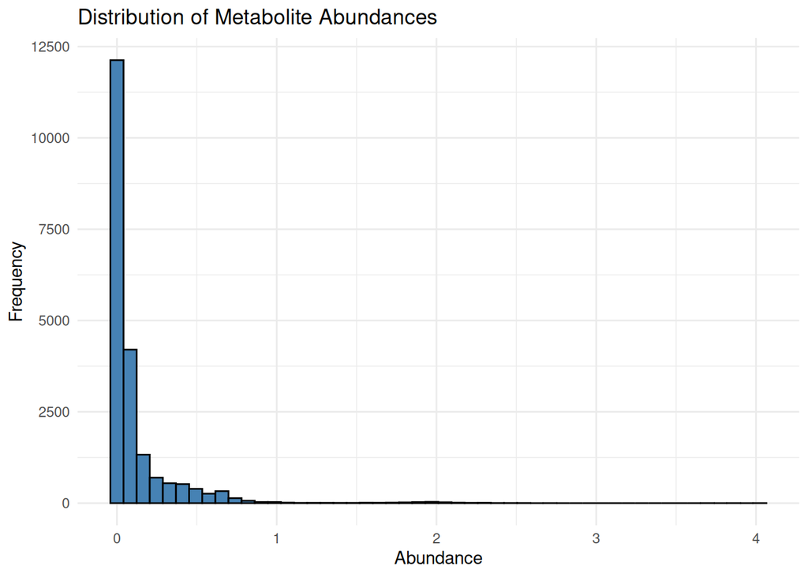

```r
ggplot(abundance_long, aes(x = Abundance)) +
  geom_histogram(bins = 50,
                 fill = "steelblue",
                 color = "black") +
  labs(
    title = "Distribution of Metabolite Abundances",
    x = "Abundance",
    y = "Frequency"
  ) +
  theme_minimal()
```

Plot abundance distribution (raw data) Log₂ transformation Plot transformed abundance distribution Continue with downstream analyses (PCA, statistical testing, etc.)

Transpose command is (t())

Next: Log₂ transformation

This is one of the most important preprocessing steps in metabolomics.

Why do we log-transform?

A log₂ transform makes equal fold changes more comparable.

Why log2(x + 1)? The +1 prevents problems if a value is zero, because:log2(0) is undefined.

```r
analysis_log <- analysis_imputed |>
  mutate(
    across(
      -c(Sample, Diagnosis, Stage),
      ~ log2(. + 1)
    )
  )
```

What does this mean biologically?

LC-MS metabolomics data almost always look like this before preprocessing.

A few metabolites are present at relatively high abundance, while many are present at much lower abundance. This produces the characteristic right-skewed distribution I am seeing.

Because of that, it’s standard practice to apply a log transformation before PCA. The log compresses the high values more than the low values, making the distribution more symmetric and reducing the influence of extreme values.

We’ll impute the missing values using a tidyverse-friendly approach and discuss why we choose that particular imputation method, rather than just applying it. That way I’ll understand both the code and the reasoning behind it. Before we log-transform…

We need to address one issue first.

Some metabolite values are missing (NA). We have two sensible options:

Impute the missing values first, then apply the log transformation. This is the workflow used in many metabolomics pipelines. Remove metabolites with excessive missingness, then impute the remaining missing values.

Since our highest missing rate is only 16.6%, we are keeping all 99 metabolites and imputing the missing values. We’ll impute the missing values using a tidyverse-friendly approach and discuss why we choose that particular imputation method, rather than just applying it. That way we’ll understand both the code and the reasoning behind it. #across(where(is.numeric), …) means Apply the same operation to every numeric column (all 99 metabolites). half_min <- min(., na.rm = TRUE) / 2  
For each metabolite, find its smallest observed value and divide it by two. if_else(is.na(.), half_min, .) This says:

If the value is missing (NA), replace it with half_min. Otherwise, keep the original value.

Now verify that the transformation worked by looking at a few values:

```r
analysis_log |>
  select(Sample, Arginine) |>
  head()
```

```
## # A tibble: 6 × 2
##   Sample  Arginine
##   <chr>      <dbl>
## 1 PN01935   0.0930
## 2 PN02020   0.0785
## 3 PN02212   0.164
## 4 PN02261   0.0812
## 5 PN02307   0.0949
## 6 PN02394   0.0831
```

or compare the original and transformed values:

```r
analysis_imputed |>
  select(Sample, Arginine) |>
  head()
```

```
## # A tibble: 6 × 2
##   Sample  Arginine
##   <chr>      <dbl>
## 1 PN01935   0.0666
## 2 PN02020   0.0559
## 3 PN02212   0.120
## 4 PN02261   0.0579
## 5 PN02307   0.068
## 6 PN02394   0.0593
```

```r
analysis_log |>
  select(Sample, Arginine) |>
  head()
```

```
## # A tibble: 6 × 2
##   Sample  Arginine
##   <chr>      <dbl>
## 1 PN01935   0.0930
## 2 PN02020   0.0785
## 3 PN02212   0.164
## 4 PN02261   0.0812
## 5 PN02307   0.0949
## 6 PN02394   0.0831
```

Next step (as in our original workflow)

Now plot the distribution after the log₂ transformation.

```r
abundance_log <- analysis_log |>
  pivot_longer(
    cols = -c(Sample, Diagnosis, Stage),
    names_to = "Metabolite",
    values_to = "Abundance"
  )
```

Now let us ccreate the histogram

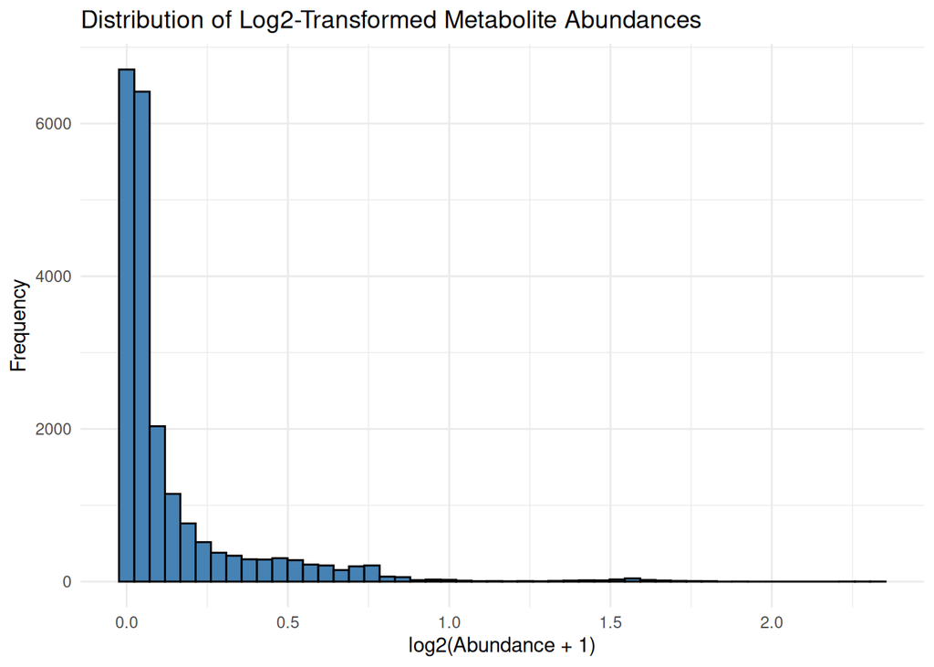

```r
ggplot(abundance_log, aes(x = Abundance)) +
  geom_histogram(
    bins = 50,
    fill = "steelblue",
    color = "black"
  ) +
  labs(
    title = "Distribution of Log2-Transformed Metabolite Abundances",
    x = "log2(Abundance + 1)",
    y = "Frequency"
  ) +
  theme_minimal()
```

The metabolite abundance data were log₂(x + 1)-transformed following half-minimum imputation. The transformation reduced the effect of highly abundant metabolites and compressed the dynamic range of the data. Although the distribution remained moderately right-skewed, it was less influenced by extreme values and was more suitable for subsequent statistical analyses.

This histogram matches what I would expect from this dataset.

One more preprocessing step remains: scaling

This is arguably the most important step before PCA.

Imagine two metabolites:

Metabolite Typical range A 0.01–0.05 B 0.5–2.0

Even after log transformation, metabolite B has much larger variability than metabolite A. If we run PCA now, metabolites with larger variance will dominate the principal components.

Scaling adjusts for this.

The three common choices are: Method Used in metabolomics? Effect None Rare Large-variance metabolites dominate Autoscaling (z-score) Very common Every metabolite gets equal variance Pareto scaling Very common Reduces dominance while preserving some biological differences xactly. This is the last preprocessing step before PCA.

Why scaling is needed

After log₂ transformation, metabolites are still measured on different scales. For example:

Metabolite Typical range A 0.01–0.05 B 0.5–2.0

Without scaling, metabolite B has much larger variance, so it contributes much more to the principal components than metabolite A. PCA is variance-based, so this can bias the results.

Scaling puts metabolites on a more comparable scale.

Common scaling methods Method Used in metabolomics? Effect None Rare Large-variance metabolites dominate Autoscaling (z-score) Very common Each metabolite has mean = 0 and SD = 1 Pareto scaling Very common Reduces dominance but preserves some variance differences

For this workflow, we’ll use autoscaling (z-score scaling), which is the most common choice before PCA. Apply Autoscaling in R

```r
analysis_scaled <- analysis_log |>
  mutate(
    across(
      -c(Sample, Diagnosis, Stage),
      ~ as.numeric(scale(.))
    )
  )
```

The scale() function:

subtracts the mean from each metabolite, divides by its standard deviation, results in each metabolite having: mean ≈ 0 standard deviation ≈ 1 Verify the scaling

For example, check Arginine:

```r
mean(analysis_scaled$Arginine)
```

```
## [1] 2.04433e-16
```

```r
sd(analysis_scaled$Arginine)
```

```
## [1] 1
```

The mean is essentially 0 (2.04 × 10⁻¹⁶ is just floating-point rounding error), and the standard deviation is exactly 1.

This confirms that the autoscaling was applied correctly.

At this point, analysis_scaled is the dataset I should use for PCA.

Next step: Principal Component Analysis (PCA)

We’ll extract the metabolite matrix (excluding the metadata) and run PCA.

```r
pca_data <- analysis_scaled |>
  select(-Sample, -Diagnosis, -Stage)
```

Then perform PCA:

```r
pca_result <- prcomp(
  pca_data,
  center = FALSE,
  scale. = FALSE
)
```

Notice that we set center = FALSE and scale. = FALSE because we have already centered and scaled the data using scale(). Applying centering and scaling again would be redundant.

After that, we’ll create a PCA scores plot by diagnosis to see whether the breast cancer and control samples separate along the principal components.

Great! Let’s perform the PCA and then visualize the results.

Step 1: Extract the metabolite matrix

```r
pca_data <- analysis_scaled |>
  select(-Sample, -Diagnosis, -Stage)
```

RUN PCA

```r
pca_result <- prcomp(
  pca_data,
  center = FALSE,
  scale. = FALSE
)
```

Create a data frame of the PCA scores

```r
pca_scores <- as.data.frame(pca_result$x) |>
  bind_cols(
    analysis_scaled |>
      select(Sample, Diagnosis, Stage)
  )
```

Calculate the variance explained

```r
variance <- pca_result$sdev^2 / sum(pca_result$sdev^2)
variance
```

```
##  [1] 1.232725e-01 9.218137e-02 7.377245e-02 6.022902e-02 5.316241e-02
##  [6] 4.249300e-02 3.626973e-02 3.042048e-02 2.968673e-02 2.525299e-02
## [11] 2.246365e-02 2.147867e-02 1.997034e-02 1.768153e-02 1.661226e-02
## [16] 1.611515e-02 1.545072e-02 1.500513e-02 1.373857e-02 1.342409e-02
## [21] 1.230878e-02 1.174259e-02 1.117358e-02 1.061201e-02 1.005826e-02
## [26] 9.823371e-03 9.736325e-03 9.216630e-03 8.910123e-03 8.556250e-03
## [31] 7.819947e-03 7.641261e-03 7.371333e-03 7.135637e-03 7.006273e-03
## [36] 6.495774e-03 6.371118e-03 6.042312e-03 5.702612e-03 5.286353e-03
## [41] 5.117190e-03 4.888974e-03 4.689429e-03 4.582416e-03 4.299605e-03
## [46] 4.026617e-03 3.952028e-03 3.810317e-03 3.607153e-03 3.339811e-03
## [51] 3.164770e-03 3.023186e-03 2.910049e-03 2.837633e-03 2.679783e-03
## [56] 2.539076e-03 2.392069e-03 2.292684e-03 1.970673e-03 1.917327e-03
## [61] 1.894616e-03 1.835494e-03 1.597507e-03 1.488930e-03 1.437659e-03
## [66] 1.342724e-03 1.216870e-03 1.193023e-03 1.122342e-03 1.007735e-03
## [71] 8.612485e-04 8.271642e-04 8.048051e-04 7.228705e-04 6.810063e-04
## [76] 6.140010e-04 5.883058e-04 5.631418e-04 5.062145e-04 4.877332e-04
## [81] 4.510090e-04 4.059928e-04 3.790862e-04 3.345946e-04 3.134055e-04
## [86] 2.513094e-04 2.255943e-04 2.106437e-04 1.894551e-04 1.464093e-04
## [91] 1.152802e-04 1.115334e-04 1.024200e-04 7.149082e-05 6.293190e-05
## [96] 5.362356e-05 2.780031e-05 1.272119e-05 9.220333e-06
```

The first two values of variance correspond to the proportion of variation explained by PC1 and PC2.

Step 5: Plot the PCA

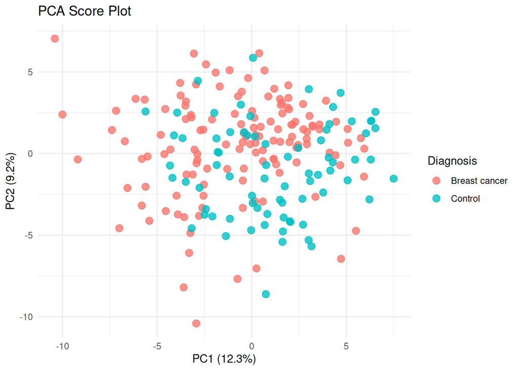

```r
library(ggplot2)

ggplot(pca_scores, aes(x = PC1, y = PC2, color = Diagnosis)) +
  geom_point(size = 3, alpha = 0.8) +
  labs(
    title = "PCA Score Plot",
    x = paste0("PC1 (", round(variance[1] * 100, 1), "%)"),
    y = paste0("PC2 (", round(variance[2] * 100, 1), "%)")
  ) +
  theme_minimal()
```

This PCA score plot will show whether the breast cancer and control samples cluster separately based on their metabolomic profiles.

whether the groups separate, whether there are any outliers, and what the percentage of variance explained by PC1 and PC2 tells us. This looks good, and it’s actually a fairly typical PCA result for a biological dataset.

Interpretation

1. PC1 explains 12.3% of the variance

PC1 captures the largest source of variation in the metabolomics data. However, it only explains 12.3%, which means the variation is spread across many metabolites rather than being driven by a few.

2. PC2 explains 9.2% of the variance

PC2 captures the second-largest independent source of variation. Together, PC1 and PC2 explain about 21.5% of the total variance.

3. Group separation

The breast cancer (pink) and control (blue) samples show substantial overlap. There is no clear separation between the two groups on the first two principal components. This suggests that the largest sources of variation in the metabolite profiles are not solely due to diagnosis.

4. Outliers

There are a few samples toward the edges of the plot (for example, around PC1 ≈ -10 or PC2 ≈ -10), but none appear to be extremely isolated from the rest of the data. I wouldn’t consider them strong outliers based on this PCA alone. Interpretation I could use in a report

PCA was performed on the log₂-transformed and autoscaled metabolomics data. The first two principal components explained 12.3% and 9.2% of the total variance, respectively. The PCA score plot showed considerable overlap between breast cancer and control samples, indicating that the overall metabolomic profiles were not clearly separated by diagnosis based on the first two principal components. No extreme outliers were observed.

Next step

The next thing we did in the workflow was to determine which metabolites differ significantly between breast cancer and controls using univariate statistical analysis (typically a t-test or Wilcoxon test, depending on assumptions), followed by visualization with a volcano plot.

That complements the PCA nicely:

PCA asks: Do the overall metabolomic profiles separate? Differential analysis asks: Which individual metabolites differ between the groups?

Perfect—we’ll continue with Step 3: Differential metabolite analysis.

The goal is to identify which metabolites differ significantly between the breast cancer and control groups.

Step 1: Perform a t-test for every metabolite

Run the following code:

```r
library(dplyr)
library(purrr)
library(tibble)

metabolite_names <- analysis_scaled |>
  select(-Sample, -Diagnosis, -Stage) |>
  names()

ttest_results <- map_dfr(metabolite_names, function(met) {

  test <- t.test(
    analysis_scaled[[met]] ~ analysis_scaled$Diagnosis
  )

  tibble(
    Metabolite = met,
    Mean_BreastCancer = mean(
      analysis_scaled[[met]][analysis_scaled$Diagnosis == "Breast cancer"]
    ),
    Mean_Control = mean(
      analysis_scaled[[met]][analysis_scaled$Diagnosis == "Control"]
    ),
    Log2FC = Mean_BreastCancer - Mean_Control,
    P_value = test$p.value
  )
})
```

Step 2: Correct for multiple testing

Since we’re testing 99 metabolites, we should control the false discovery rate (FDR).

Run:

```r
ttest_results <- ttest_results |>
  mutate(
    FDR = p.adjust(P_value, method = "BH")
  ) |>
  arrange(P_value)
```

View the most significant metabolites

```r
head(ttest_results, 10)
```

```
## # A tibble: 10 × 6
##    Metabolite            Mean_BreastCancer Mean_Control Log2FC  P_value      FDR
##    <chr>                             <dbl>        <dbl>  <dbl>    <dbl>    <dbl>
##  1 Glycerophosphocholine            -0.495        0.880 -1.38  2.69e-21 2.67e-19
##  2 Glutamine                         0.417       -0.740  1.16  2.95e-19 1.46e-17
##  3 Lysine                            0.389       -0.691  1.08  9.13e-15 3.01e-13
##  4 Butyrylcarnitine                  0.214       -0.380  0.593 3.29e- 7 8.14e- 6
##  5 Pentosidine                      -0.333        0.591 -0.924 4.80e- 7 9.51e- 6
##  6 Propionylcarnitine                0.226       -0.402  0.629 6.20e- 7 1.02e- 5
##  7 Uracil                            0.225       -0.400  0.625 3.07e- 6 4.34e- 5
##  8 Phenyllactic acid                -0.300        0.534 -0.834 6.82e- 6 8.43e- 5
##  9 Nicotinuric acid                 -0.266        0.473 -0.739 1.95e- 5 2.15e- 4
## 10 Bilirubin                         0.197       -0.349  0.546 3.54e- 5 3.50e- 4
```

This will show the 10 metabolites with the smallest p-values, along with their:

Mean abundance in breast cancer Mean abundance in controls Log2 fold change Raw p-value FDR-adjusted p-value

Here’s how to interpret the first few:

Metabolite Higher in Glycerophosphocholine Control (mean = 0.88 vs -0.50) Glutamine Breast cancer (0.42 vs -0.74) Lysine Breast cancer Butyrylcarnitine Breast cancer Pentosidine Control Propionylcarnitine Breast cancer Uracil Breast cancer Phenyllactic acid Control Nicotinuric acid Control Bilirubin Breast cancer

Remember that because we autoscaled the data:

A positive mean indicates the group has above-average abundance for that metabolite. A negative mean indicates below-average abundance. The Log2FC column (difference between the group means) tells me both the direction and magnitude of the difference. Before we make a volcano plot

Let’s check how many metabolites are statistically significant after correcting for multiple testing (FDR).

Run:

```r
sum(ttest_results$FDR < 0.05)
```

```
## [1] 42
```

```r
ttest_results |>
  filter(FDR < 0.05)
```

```
## # A tibble: 42 × 6
##    Metabolite            Mean_BreastCancer Mean_Control Log2FC  P_value      FDR
##    <chr>                             <dbl>        <dbl>  <dbl>    <dbl>    <dbl>
##  1 Glycerophosphocholine            -0.495        0.880 -1.38  2.69e-21 2.67e-19
##  2 Glutamine                         0.417       -0.740  1.16  2.95e-19 1.46e-17
##  3 Lysine                            0.389       -0.691  1.08  9.13e-15 3.01e-13
##  4 Butyrylcarnitine                  0.214       -0.380  0.593 3.29e- 7 8.14e- 6
##  5 Pentosidine                      -0.333        0.591 -0.924 4.80e- 7 9.51e- 6
##  6 Propionylcarnitine                0.226       -0.402  0.629 6.20e- 7 1.02e- 5
##  7 Uracil                            0.225       -0.400  0.625 3.07e- 6 4.34e- 5
##  8 Phenyllactic acid                -0.300        0.534 -0.834 6.82e- 6 8.43e- 5
##  9 Nicotinuric acid                 -0.266        0.473 -0.739 1.95e- 5 2.15e- 4
## 10 Bilirubin                         0.197       -0.349  0.546 3.54e- 5 3.50e- 4
## # ℹ 32 more rows
```

Next: Create a volcano plot

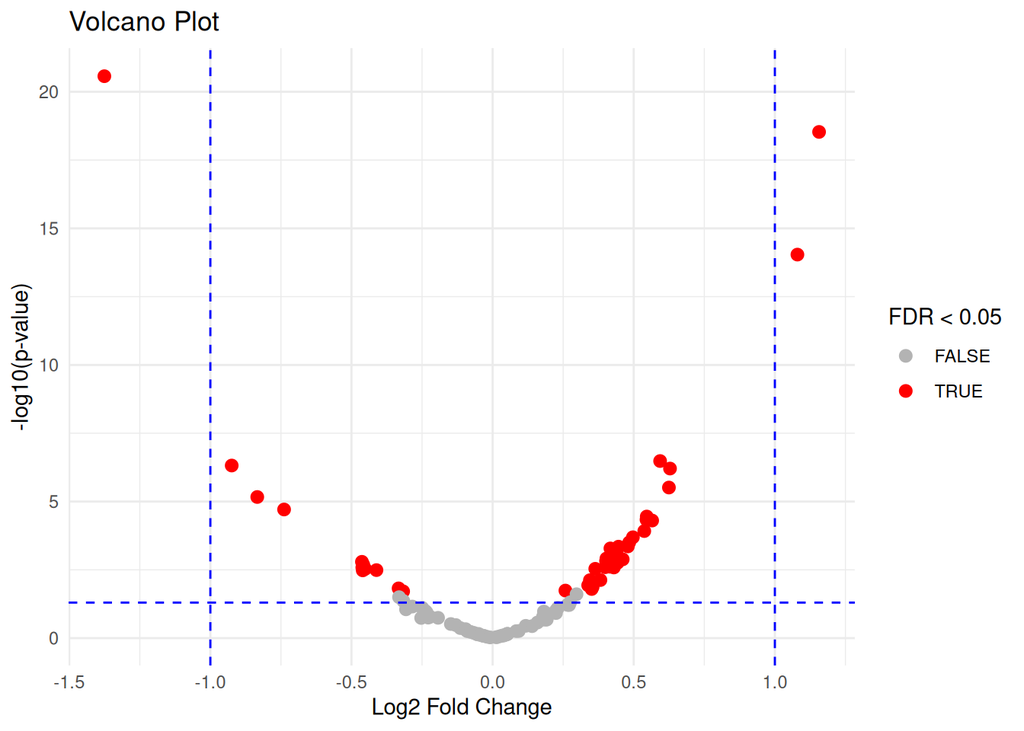

```r
library(ggplot2)

ggplot(ttest_results,
       aes(x = Log2FC,
           y = -log10(P_value))) +
  geom_point(aes(color = FDR < 0.05), size = 2.5) +
  scale_color_manual(values = c("grey70", "red")) +
  geom_vline(xintercept = c(-1, 1),
             linetype = "dashed",
             color = "blue") +
  geom_hline(yintercept = -log10(0.05),
             linetype = "dashed",
             color = "blue") +
  labs(
    title = "Volcano Plot",
    x = "Log2 Fold Change",
    y = "-log10(p-value)",
    color = "FDR < 0.05"
  ) +
  theme_minimal()
```

This looks excellent—it has the classic volcano plot shape and suggests our analysis pipeline has worked correctly.

Optional improvement: Label the significant metabolites

A volcano plot is much easier to interpret if the significant metabolites are labeled. If we’re using ggrepel, we can add labels like this:

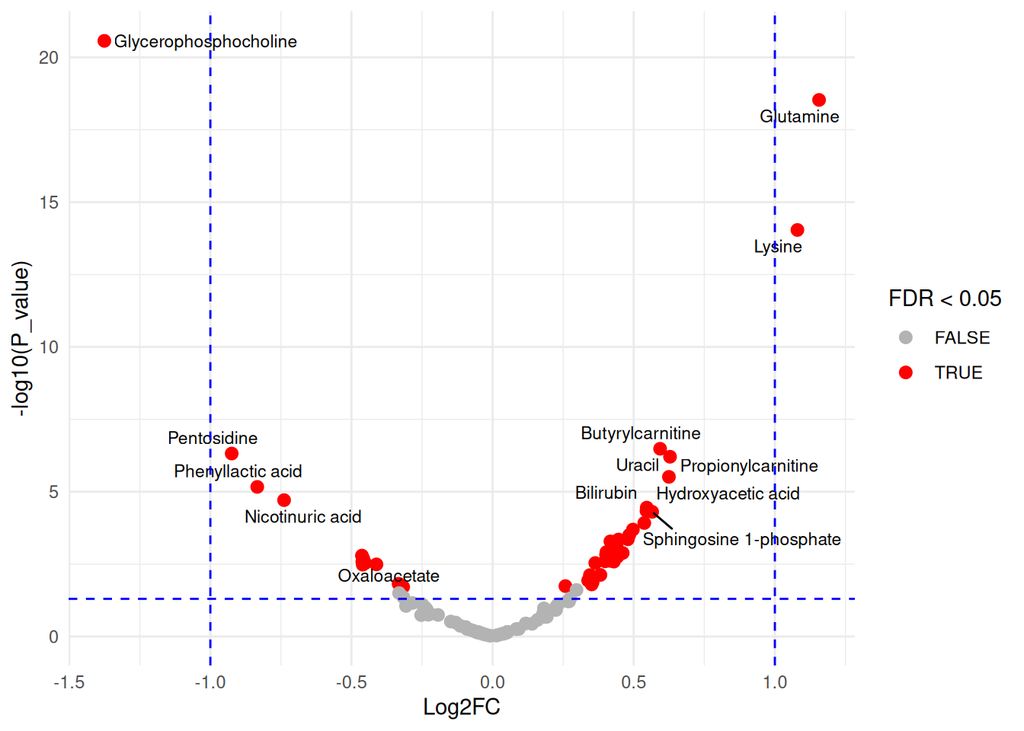

```r
library(ggrepel)

ggplot(ttest_results,
       aes(x = Log2FC,
           y = -log10(P_value))) +
  geom_point(aes(color = FDR < 0.05), size = 2.5) +
  geom_text_repel(
    data = subset(ttest_results, FDR < 0.05),
    aes(label = Metabolite),
    size = 3
  ) +
  scale_color_manual(values = c("grey70", "red")) +
  geom_vline(xintercept = c(-1, 1), linetype = "dashed", color = "blue") +
  geom_hline(yintercept = -log10(0.05), linetype = "dashed", color = "blue") +
  theme_minimal()
```

The published paper compared ER-positive and ER-negative breast cancers, whereas my analysis compared all breast cancer samples with healthy controls. Therefore, the biological comparison is different. Glutamine may be elevated overall in breast cancer relative to controls, while being depleted specifically in ER-negative tumors due to increased glutamine utilization. These findings are not necessarily contradictory.”

That is a scientifically sound explanation.

Check

```r
table(analysis_scaled$Diagnosis)
```

```
##
## Breast cancer       Control
##           135            76
```

The published paper compared ER-positive and ER-negative breast cancers, whereas my analysis compared all breast cancer samples with healthy controls. Therefore, the biological comparison is different. Glutamine may be elevated overall in breast cancer relative to controls, while being depleted specifically in ER-negative tumors due to increased glutamine utilization. These findings are not necessarily contradictory.”

That is a scientifically sound explanation.

Run

```r
analysis_scaled %>%
  group_by(Diagnosis) %>%
  summarise(mean_glutamine = mean(Glutamine))
```

```
## # A tibble: 2 × 2
##   Diagnosis     mean_glutamine
##   <chr>                  <dbl>
## 1 Breast cancer          0.417
## 2 Control               -0.740
```

```r
aggregate(Glutamine ~ Diagnosis, data = analysis_scaled, mean)
```

```
##       Diagnosis  Glutamine
## 1 Breast cancer  0.4166061
## 2       Control -0.7400240
```